# Data Wrangling for EDSDers

7-10 Nov, 2022 Tim Riffe Universidad del País Vasco & Ikerbasque (Basque Foundation for Science)

9 Nov, 2022

# 1 Introduction

In this script weŕe going to combine a demographic dataset (World Population Prospects) with a sociological dataset (World Value Survey). Both cover a range of years and either all or most countries of the world. In order to join the two datasets we’ll need to do do some pre-harmonization in order to get them joinable. This will consist in getting both datasets tidy, giving consistently named and coded columns on which to join them.

For the most recent WPP data we’ll want to download a package from GitHub, which you can do like so:

```r
library(remotes)
options(timeout = 600)
install_github("PPgp/wpp2022")
```

Packages we’ll use:

```r
library(here)
library(tidyverse)
library(wpp2022)
library(haven)
```

# 2 World Value Survey (WVS)

The data consist in individual respondents as the unit of observation, and we’ll want to get an aggregate out of it. We need to do the following operations to WVS in order to get it joinable:

1. We need to browse the documentation to figure out what variable to focus on. Ideally available in most of the individual surveys (we’ll check it’s mostly not missing)
2. Age should either be in clean single ages or clean grouped ages. So we should decide that explicitly and ensure both data sources conform. I’ll choose 5-year age groups here.
3. Likewise for years: WVS gives exact years, whereas the time granularity of WPP depends which files we take (either 1 or 5).
4. We need to get some sort of prevalence or mean measure per 5-year age group in some interesting variable (by year, age, sex and country). We can do this using the `summarize()` function instead of regression. Regression would be better though because we’d be able to smooth and impute missing ages.

Here we read in the data, which we downloaded already in one of `R`’s native formats (`.rdata`), which can be `load()`ed into the workspace. At this point we were also browsing the spreadsheet that comes with the data. We need that spreadsheet to know which columns to grab, since they’re just alphanumeric codes. By the way, I manually renamed the `.rdata` file to `WVS.rdata` to make it easier to remember. This is the one I’ll share in class.

```r
load("Data/WVS.rdata")
# The name is weird, let's shorten it
WVS <- WVS_TimeSeries_1981_2022_spss_v3_0
# remove the old one
rm(WVS_TimeSeries_1981_2022_spss_v3_0)

print(object.size(WVS), units = "Gb")
```

```
## 1.8 Gb
```

This dataset has codes for variable names, so we should refer to the spreadsheet of variable descriptions and equivalencies that ships with it to pick out and rename the ones we’re potentially interested in.

```r
#colnames(WVS)
# country code
unique(WVS$S003)
```

```
##   [1]   8  12  20  32  51  36  31  50 112  68  70  76 100 854 124 170 191
##  [18] 196 203 152 156 214 218 818 222 233 231 246 250 268 276 288 300 320
##  [35] 332 344 348 356 360 364 368 376 380 392 400 398 404 414 417 428 422
##  [52] 434 440 446 458 466 484 498 496 499 504 104 528 554 558 566 807 578
##  [69] 586 275 604 608 616 630 634 642 643 646 682 688 702 703 705 710 410
##  [86] 724 752 756 158 762 834 764 780 788 792 800 826 804 840 858 860 862
## [103] 704 887 894 716
```

```r
# year
unique(WVS$S020)
```

```
##  [1] 1998 2002 2014 2005 2018 1984 1991 1995 1999 2006 2013 2017 1997 2011
## [15] 2021 1981 2012 1996 1990 2001 2007 1982 2000 2020 2019 2008 2009 2004
## [29] 2016 2010 2003 2022 1989
```

```r
# sex
unique(WVS$X001)
```

```
## [1]  2  1 -1 -2 -5 -4
```

```r
# age
sort(unique(WVS$X003))
```

```
##  [1]  -5  -4  -3  -2  -1  13  14  15  16  17  18  19  20  21  22  23  24
## [18]  25  26  27  28  29  30  31  32  33  34  35  36  37  38  39  40  41
## [35]  42  43  44  45  46  47  48  49  50  51  52  53  54  55  56  57  58
## [52]  59  60  61  62  63  64  65  66  67  68  69  70  71  72  73  74  75
## [69]  76  77  78  79  80  81  82  83  84  85  86  87  88  89  90  91  92
## [86]  93  94  95  96  97  98  99 100 102 103
```

```r
# A015 "People can be trusted"
table(WVS$A165)
```

```
##
##     -4     -2     -1      1      2
##   2988   4030  10469 110300 312268
```

```r
# S017 person weight (any will do for this exercise)
```

```r
WVS_to_join <-
  WVS %>%
  # remove variable labels
  zap_labels() %>%
  # grab variables we need
  select(loc_id = S003,
         year = S020, # Year
         sex = X001, # Sex
         age = X003, # age
         trust = A165,
         pwt = S017) %>%  # trust
  #pull(sex) %>% table() # spot check for negative age
  # remove missings, nothing fancy here, and no
  # reason to get hung up on it.
  filter(age >= 0,
         trust > 0,
         sex > 0) %>%
  # bin to 5-year Lexis cells, recoded trust
  mutate(#year = year - year %% 5,
         age = age - age %% 5,
         distrust = trust - 1,
         trust = 1 - distrust,
         sex = if_else(sex == 1, "male", "female")) %>%
  # tabulate (two steps)
  group_by(loc_id, sex, year, age) %>%
  summarize(trust = sum(trust * pwt) / sum(pwt),

            distrust = sum(distrust * pwt) / sum(pwt),
            .groups = "drop")
```

# 3 World Population Prospects (WPP)

The UN uses the same country codes, and ships its data as aggregates in a different formats, some basically tidy, others wide: From the `wpp2022` Division (2022). This package consists in a bunch of datasets, including denominators, rates, and indices. We opted to calculate a Sullivan estimate of trust expectancy, and for this we’ll want lifetable exposure `nLx`, which isn’t included in the package. We can calculate it from `nMx`, however, which is available in in detailed age in the dataset called `mx1dt`.

```r
data(mx1dt)
# glimpse(mxF)
# check country code overlap, 106 countries!
intersect(unique(mx1dt$country_code),unique(WVS_to_join$loc_id))
```

```
##   [1] 231 404 646 800 834 894 716  12 818 434 504 788 710 854 288 466 566
##  [18] 398 417 762 860 156 344 446 158 392 496 410  50 356 364 586 360 458
##  [35] 104 608 702 764 704  51  31 196 268 368 376 400 414 422 634 682 275
##  [52] 792 887 112 100 203 348 616 498 642 643 703 804 233 246 428 440 578
##  [69] 752 826   8  20  70 191 300 380 499 807 688 705 724 250 276 528 756
##  [86] 214 332 630 780 222 320 484 558  32  68  76 152 170 218 604 858 862
## [103] 124 840  36 554
```

The first step will be to reshape, stacking the sex-specific rates

```r
#str(mx1dt)
mx1dt <-
  mx1dt %>%
  pivot_longer(c(mxF,mxM),
               names_to = "sex",
               values_to = "mx") %>%
  mutate(sex = case_when(sex == "mxF" ~"female",
                         sex == "mxM" ~ "male",
                         sex == "mxB" ~ "total")) %>%
  rename(loc_id = country_code)
```

Now we’re ready for the WPP pipeline, which will include some lifetable calculations. Some of them fit cleanly into `mutate()` and others are nicer to wrap in helper function like this one, which can also be used inside `mutate()`

```r
px_to_lx <- function(px){
  n <- length(px)
  c(1,cumprod(px)[-n])
}
```

```r
# send it down the pipe
wpp_to_join <-
  mx1dt %>%
  mutate(ax = .5,
         qx = ifelse(age == 100,
                     1,
                     mx / (1 + (1 - ax) * mx))) %>%
  arrange(loc_id, sex, year, age) %>%
  group_by(loc_id, sex, year) %>%
  mutate(px = 1 - qx,
         lx = px_to_lx(px),
         dx = qx * lx,
         Lx = dx / mx) %>%
  ungroup() %>%
  filter(year >= 1980,
         year <= 2022) %>%
  # put in 5-year age groups
  mutate(age = age - age %% 5) %>%
  group_by(loc_id, name, year, sex, age) %>%
  summarize(Lx = sum(Lx),
            lx = lx[1],
            .groups = "drop")
```

In the middle of the pipe we see a step `arrange()`. This function sorts rows according to the variables listed from left to write. We needed to put this here because we needed `year` to be numeric for proper sorting. We need the sorting because some lifetable calculations are sequentially dependent within age. After the sorting operation, we continue lifetables *within* subsets (ergo `group_by() + mutate()`), including our above-defined helper function `px_to_lx()`, and we needn’t go further than `Lx`. Finally let’s standardize one last column name and select only those years that fall within the WVS range.

Now we’re ready to do our join operation. Look at how much overhead was needed in order to turn these two datasets into joinable things!! The lesson: you need to have 1) identically named and 2) identically coded columns on which to join. It would have been a heck of alot easier to join if we only needed to join on ISO codes! But hey, we have super awesome detailed and nested demographic data that we wish to preserve in the name of science.

# 4 The join

Here’s the join operation. Remember we looked at the `dplyr` [Data Wrangling Cheat Sheet](https://rstudio.com/wp-content/uploads/2015/02/data-wrangling-cheatsheet.pdf) to figure out which merge operation to do.

```r
Trust_table_data <- left_join(
    WVS_to_join,
    wpp_to_join,
    by = c("loc_id","sex","year","age"))
```

# 5 Final cleaning and fun

We need a helper function whose job it is to replace NAs with the average of neighboring cells. How about a linear interpolation with `approx()`?

```r
na_averager <- function(age, prev){
  ind <- is.na(prev)
  # if nothing is missing just return prev
  if (all(!ind)){
    return(prev)
  }
  # otherwise we need to do this
  approx(x = age[!ind],
         y = prev[!ind],
         xout = age,
         rule = 2)$y
}
x <- c(15,20,25,30,35,40)
y <- c(NA,.3,NA,.5,.6,NA)
# rule = 2 means tail missings are imputed as constant
na_averager(age=x, prev = y)
```

```
## [1] 0.3 0.3 0.4 0.5 0.6 0.6
```

We now start the semifinal pipeline to parse down and fill out these data. To remove superfluous lifetables, we ask for each lifetable subset (`group_by()`) whether it’s the case that each value of `trust` is an `NA` (`remove`). Then we immediately throw those cases out (`filter()`). Then we impute *occassional* `NA`s using our simple helper function `na_averager()`. By the way, we wouldn’t need to do that if prevalence had been modeled in the first place, as we could have ensured a full age range. Finally, we can calculate our summary index of trusty life expectancy at age 15 `e15trust` (and its complement).

```r
eTrust <-
  Trust_table_data %>%
  group_by(loc_id, sex, year) %>%
  mutate(remove = all(is.na(trust))) %>%
  ungroup() %>%
  filter(!remove,
         age >= 15) %>%
  group_by(loc_id, sex, year) %>%
  mutate(trust = na_averager(age,
                             prev = trust),
         distrust = 1 - trust) %>%
  summarize(e15trust = sum(Lx * trust) /
                           lx[age == 15],
            e15distrust = sum(Lx * distrust) /
                           lx[age == 15],
            .groups = "drop")
```

Note: dividing out `l15` is how we age condition the lifetable. It simply scales up `sum(Lx * trust)`. We may as well cap this off with a visualization of some kind. This is weird, but I propose *trust compression*, i.e. $e_{15}^{trust} / e_{15}$, i.e. on average what fraction of life is spent trustful. This is pure silliness, but the calculations are basically valid. So here we plot life expectancy in x and trust compression in y. Maybe longer lives go along with a larger fraction of life in trustfulness?

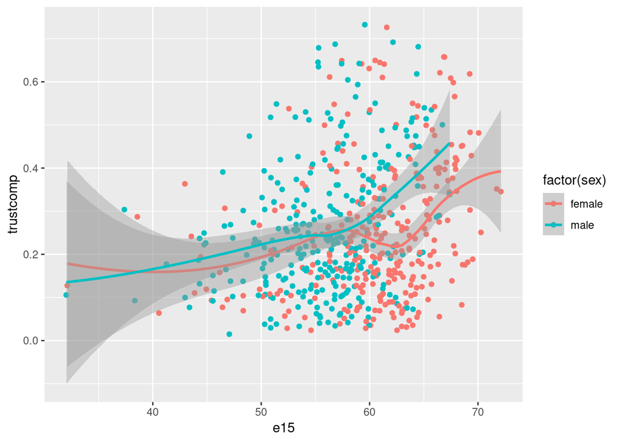

```r
eTrust %>%
  mutate(e15 = e15trust + e15distrust,
         trustcomp = e15trust / e15) %>%
  ggplot(mapping = aes(x = e15,
                       y = trustcomp,
                       color = factor(sex))) +
  geom_point() +
  geom_smooth()
```

# References

Division, United Nations Population. 2022. *Wpp2022: World Population Prospects 2022*. http://population.un.org/wpp.

Inglehart, C, R., A. Moreno Haerpfer, C. Welzel, K. Kizilova, J. Diez-Medrano, M. Lagos, P. Norris, E. Ponarin, and B. Puranen et al. 2014. “World Values Survey: All Rounds - Country-Pooled Datafile.” electronic. http://www.worldvaluessurvey.org/WVSDocumentationWVL.jsp.